# Statistic Calculate Method

## HW2 201811526 이은주

### 7-1

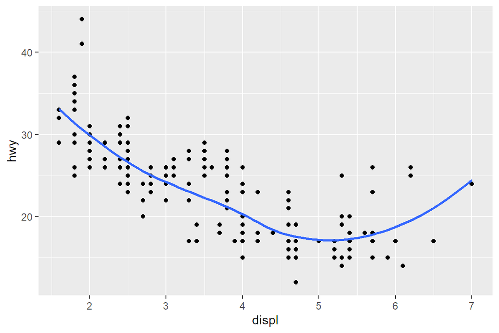

```r
mpg %>%
  ggplot(mapping=aes(x=displ, y=hwy)) +
  geom_point() + geom_smooth(se=FALSE)
```

- geom을 이용하여 산점도와 x축과 y축의 관계를 나타낸 그래프를 함께 볼 수 있다.  
  이에 따르면, 엔진배기량과 고속도로 주행 거리는 음의 상관관계를 보임을 알 수 있다.

### 7-2

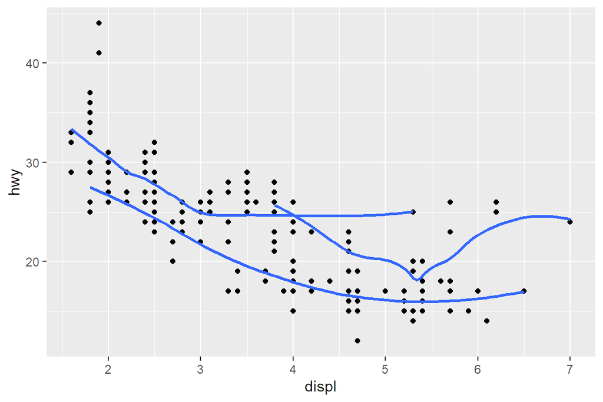

```r
mpg %>%
  ggplot(mapping=aes(x=displ, y=hwy)) +
  geom_point() + geom_smooth(aes(group=drv),se=FALSE)
```

### 7-3

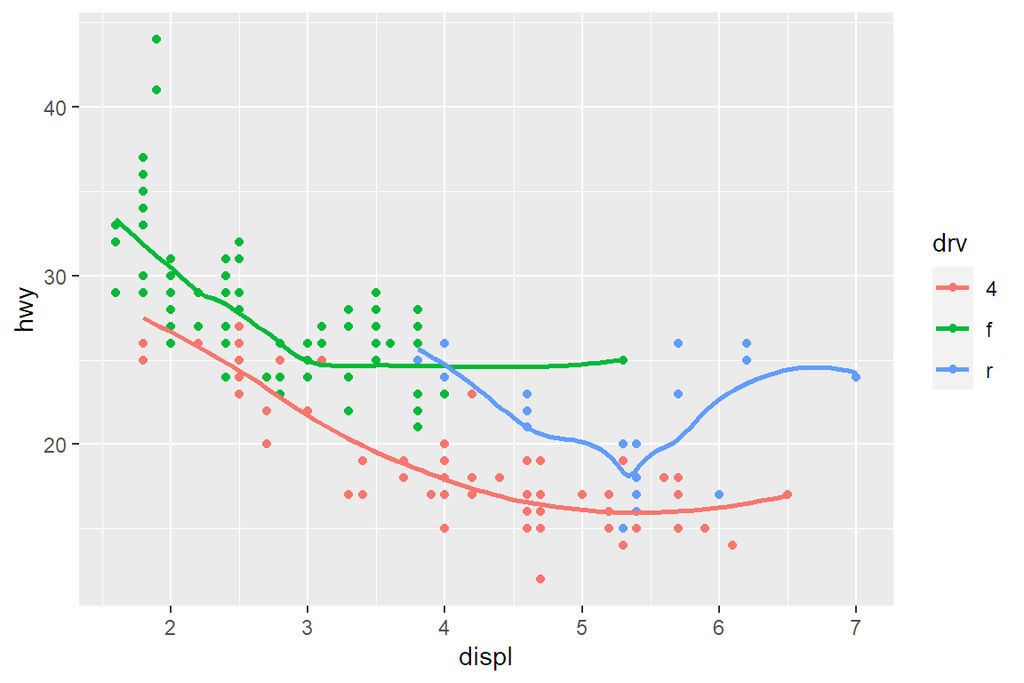

```r
mpg %>%
  ggplot(mapping=aes(x=displ, y=hwy)) +
  geom_point(aes(colour=drv)) + geom_smooth(aes(colour=drv),se=FALSE)
```

- 색깔을 열차종류 변수로 지정하여 어떤 열차의 산점도와 그래프인지 알 수 있다.  
  이를 통해 f열차는 엔진배기량이 작고 r열차는 엔진배기량이 크고  
  4열차는 다양한 엔진배기량을 사용한다는 것을 추가적으로 알 수 있다.

### 7-4

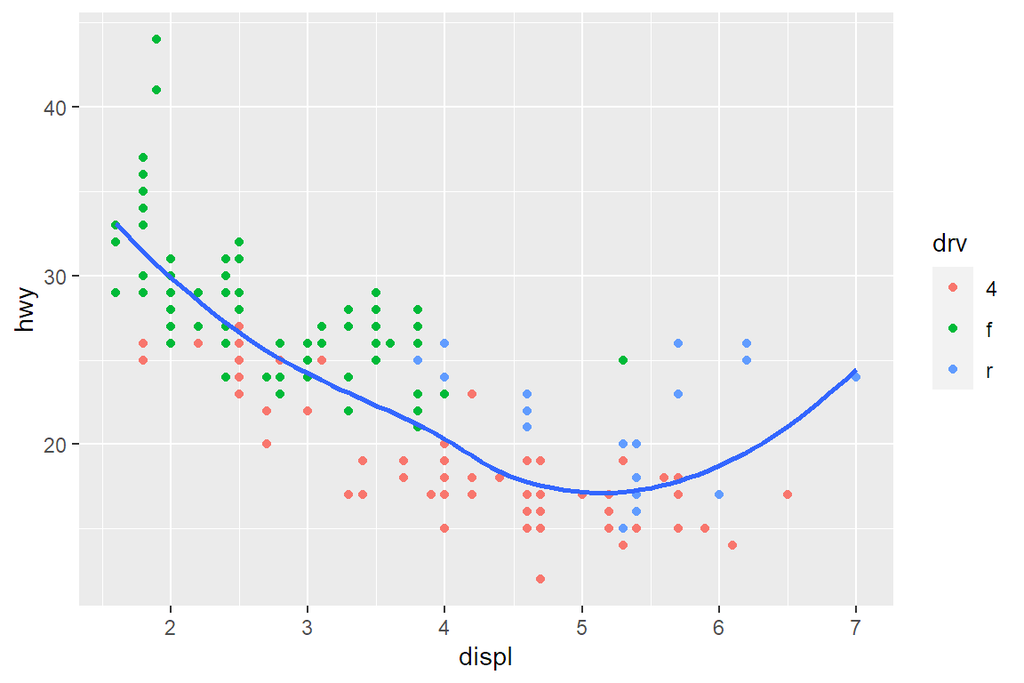

```r
mpg %>%
  ggplot(mapping=aes(x=displ, y=hwy)) +
  geom_point(aes(colour=drv)) + geom_smooth(se=FALSE)
```

- 열차 종류에 따른 엔진배기량과 주행거리의 분포를 알 수 있고  
  전반적으로 엔진배기량과 주행거리는 음의 관계에 있음을 알 수 있다.

### 7-5

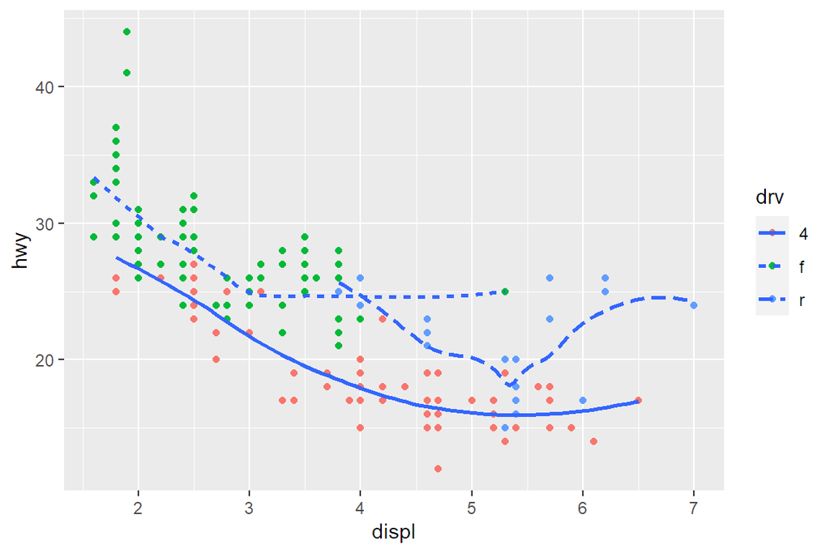

```r
mpg %>%
  ggplot(mapping=aes(x=displ, y=hwy)) +
  geom_point(aes(colour=drv)) + geom_smooth(aes(linetype=drv),se=FALSE)
```

- linetype을 열차종류 변수로 지정하여 각 종류마다 다른 선모양으로 구분할 수 있다.

### 7-6

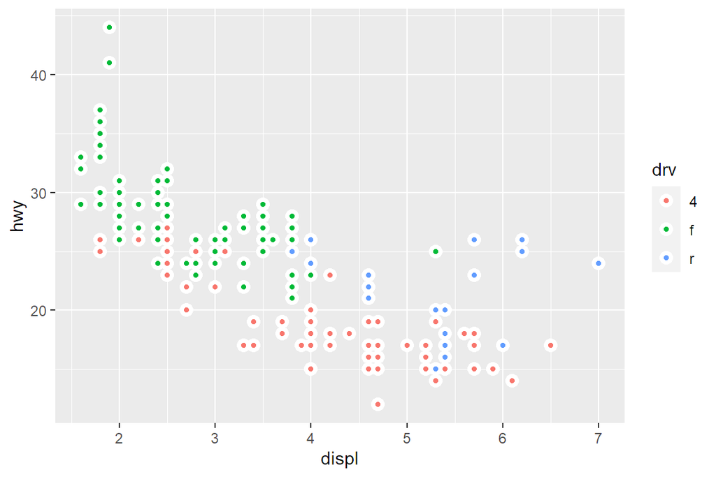

```r
mpg %>%
  ggplot(mapping=aes(x=displ, y=hwy)) +
  geom_point(mapping=aes(fill=drv), shape=21, colour="white", stroke=2)
```

- shape을 지정하면, 점의 모양을 조정할 수 있고 이때, stroke은 점의 테두리 두께를 의미한다.  
  이에 따라 점의 테투리 색은 colour로 점 안의 색은 fill로 지정해준다.